# Pre-Proccessing Data

### 1.2.5 Boxplot By Group

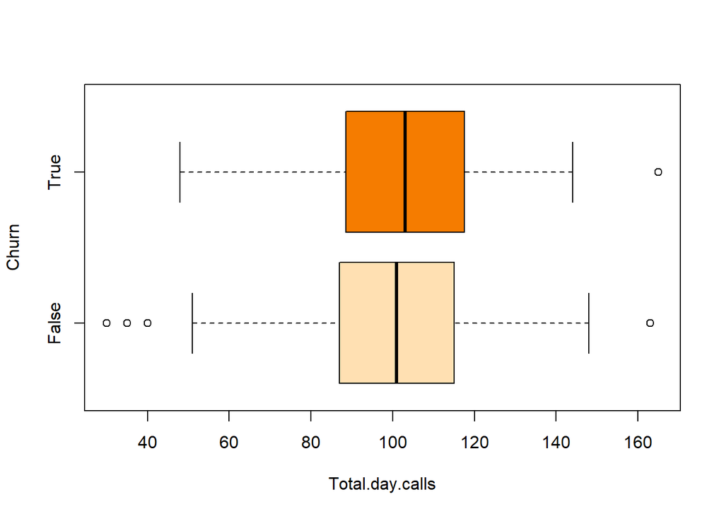

```r
boxplot(Total.day.calls ~ Churn, data = df,
        col = c("#FFE0B2", "#F57C00"), horizontal = TRUE)
```

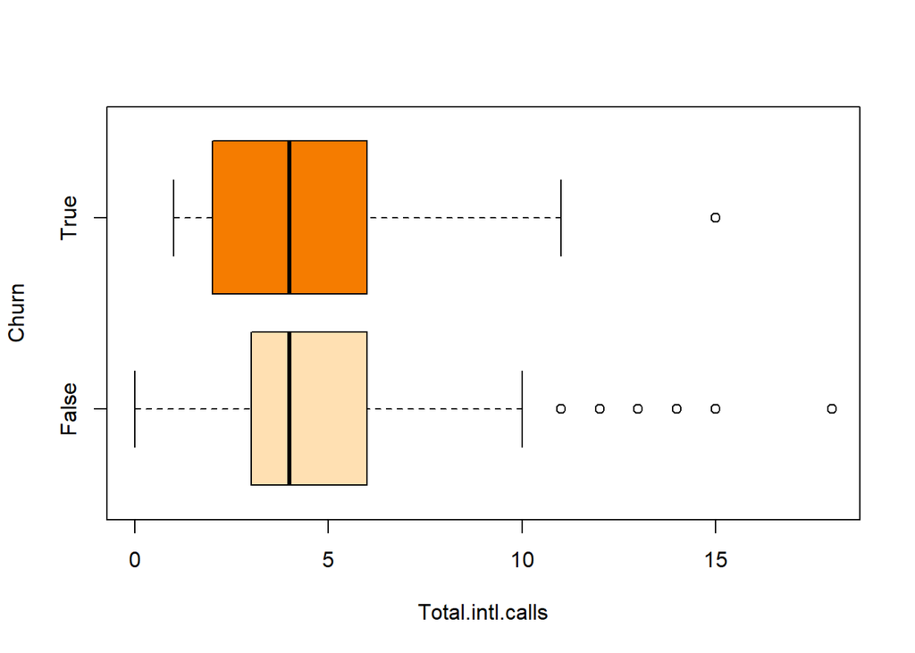

```r
boxplot(Total.intl.calls ~ Churn, data = df,
        col = c("#FFE0B2", "#F57C00"), horizontal = TRUE)
```

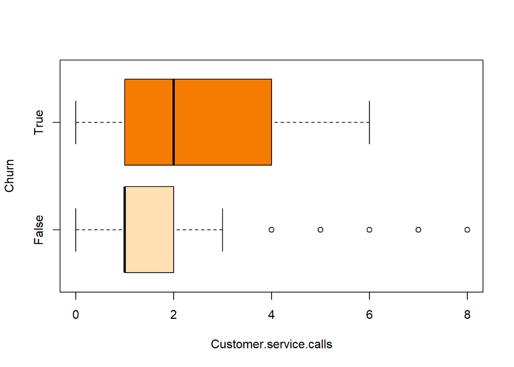

```r
boxplot(Customer.service.calls ~ Churn, data = df,
        col = c("#FFE0B2", "#F57C00"), horizontal = TRUE)
```

### 1.2.6 Layout

Membuat Layout untuk Tampilan Histogram dan Boxplot

```r
nf <- layout(mat = matrix(c(1,2), 2,1, byrow = TRUE), heights = c(3,1.5))

par(mar=c(3.1, 3.1, 2.1, 2.1))
```

#### 1.2.6.1 Histogram

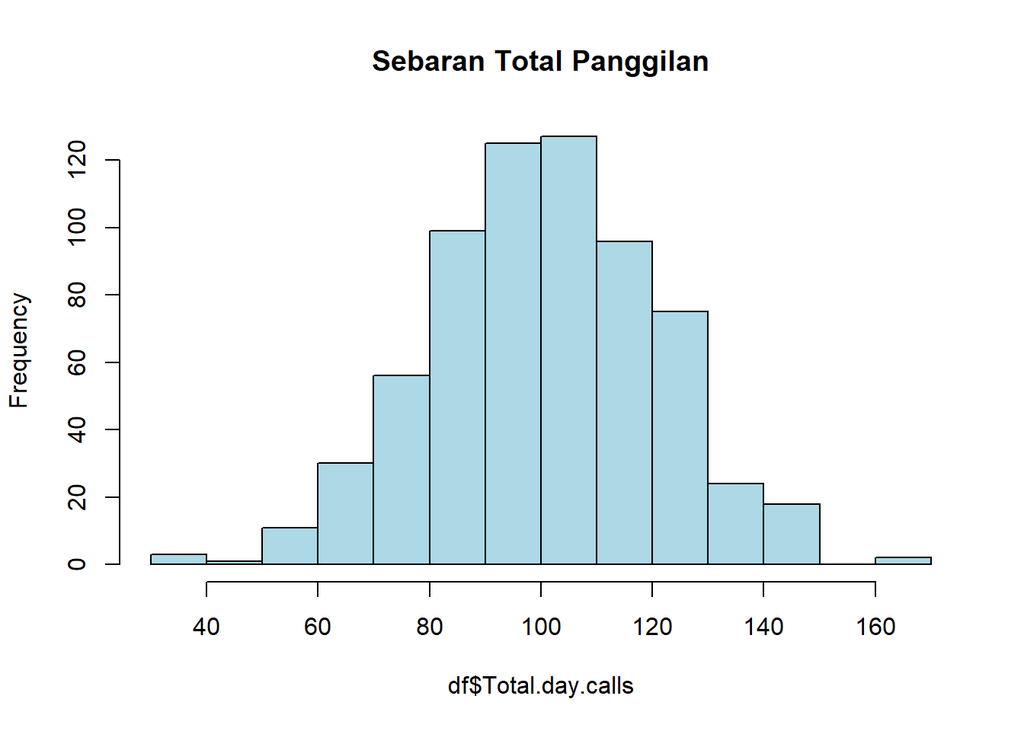

```r
hist(df$Total.day.calls, col = "lightblue", main = "Sebaran Total Panggilan")
```

#### 1.2.6.2 Boxplot

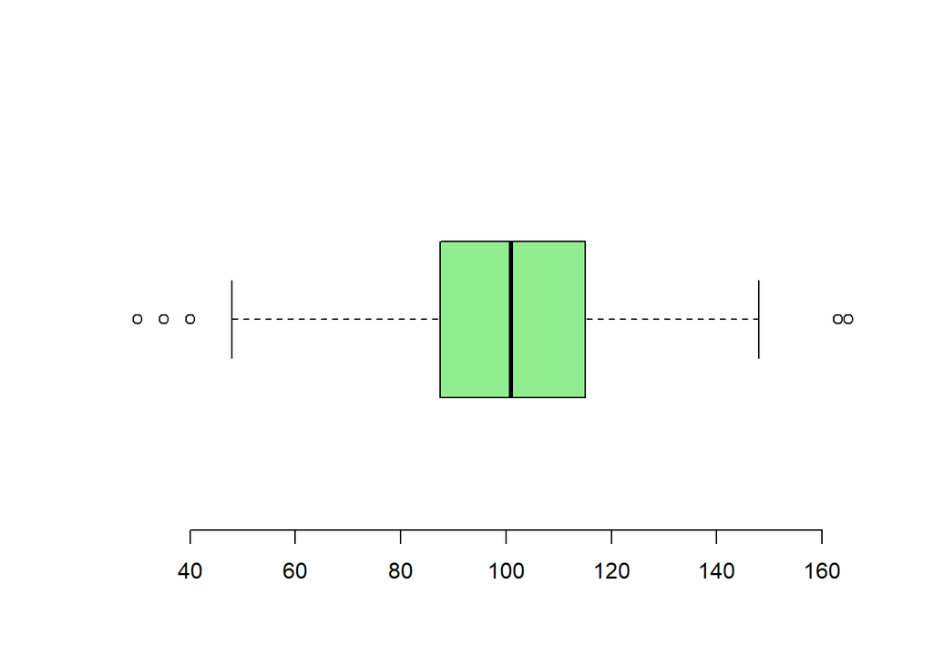

```r
boxplot(df$Total.day.calls, horizontal = T, frame = F, col = "lightgreen")
```

```r
props.1 <- table(df[,c("Churn", "International.plan")])

props.1
```

```
##        International.plan
## Churn    No Yes
##   False 538  34
##   True   76  19
```

```r
prop.table(props.1)
```

```
##        International.plan
## Churn           No        Yes
##   False 0.80659670 0.05097451
##   True  0.11394303 0.02848576
```

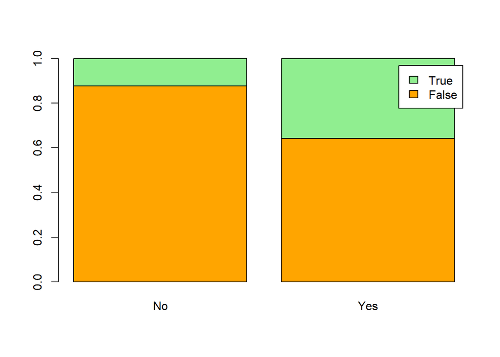

```r
barplot(prop.table(props.1, 2),
        col = c("orange", "lightgreen"),
        legend = c("False", "True"))
```

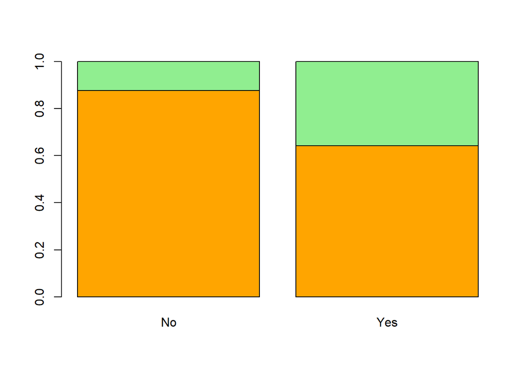

```r
barplot(prop.table(props.1, 2), col = c("orange", "lightgreen"))
```

```r
cat("Mean   :", mean(df$Total.day.calls), "\n")
```

```
## Mean   : 100.937
```

```r
cat("Median :", median(df$Total.day.calls), "\n")
```

```
## Median : 101
```

```r
# Create the function 'Modus'
getmode <- function(v) {
    uniqv <- unique(v)
    uniqv[which.max(tabulate(match(v, uniqv)))]
}

cat("Mode   :", getmode(df$Total.day.calls))
```

```
## Mode   : 102
```

```r
getmode.alt <- function(data) {
  # Hitung frekuensi kemunculan setiap nilai dalam data
  frek <- table(data)
  # Temukan nilai dengan frekuensi tertinggi
  mode <- names(frek)[which.max(frek)]
  return(mode)
}

cat("Mode   :", getmode.alt(df$Total.day.calls))
```

```
## Mode   : 102
```

## 1.3 Penyebaran Data

Ukuran Penyebaran Data

```r
ragam <- var(df$Total.day.calls)
sp.baku <- sd(df$Total.day.calls) # atau --> sqrt(var(df$Total.day.calls))
jangkauan <- range(df$Total.day.calls)
jak <- IQR(df$Total.day.calls)

cat("Ragam     :", ragam, "\n")
```

```
## Ragam     : 416.0291
```

```r
cat("Sp. Baku  :", sp.baku, "\n")
```

```
## Sp. Baku  : 20.39679
```

```r
cat("Jangkauan :", jangkauan, "\n")
```

```
## Jangkauan : 30 165
```

```r
cat("JAK       :", jak, "\n")
```

```
## JAK       : 27.5
```

### 1.3.1 Coef. of Variation

```r
cv <- sd(df$Total.day.calls)/mean(df$Total.day.calls) * 100

cat("Coefficient of Variation :", cv, "\n")
```

```
## Coefficient of Variation : 20.20744
```

### 1.3.2 Koefisien Gini

```r
# install.packages("DescTools")
library("DescTools")
gini <- DescTools::Gini(df$Total.day.calls)
cat("\n'\", Gini Coef :", gini, "\n")
```

```
##
## '", Gini Coef : 0.113967
```

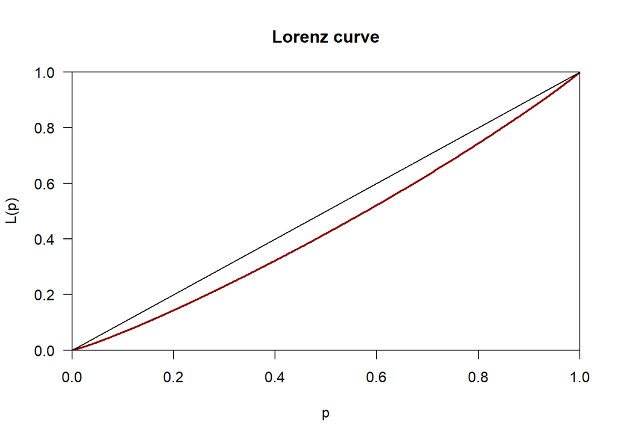

```r
plot(ineq::Lc(df$Total.day.calls),col="darkred",lwd=2)
```

### 1.3.3 Bentuk Sebaran

```r
moments::skewness(df$Total.day.calls) # Kemencengan
```

```
## [1] -0.05265871
```

```r
moments::kurtosis(df$Total.day.calls) # Keruncingan
```

```
## [1] 3.061712
```

# 2 Pima Indians Diabetes

Akan dilakukan eksplorasi pada data Pima Indians Diabetes. Memuat Pustaka yang diperlukan.

```r
library(ggplot2)
library(gridExtra)
```

```r
setwd("D:/Kuliah/Mat/TSA Kominfo/Praktikum")
diabetes <- read.csv('pima-indians-diabeter-database.csv', sep = ',')
head(diabetes)
```

```
##   Pregnancies Glucose BloodPressure SkinThickness Insulin  BMI
## 1           6     148            72            35       0 33.6
## 2           1      85            66            29       0 26.6
## 3           8     183            64             0       0 23.3
## 4           1      89            66            23      94 28.1
## 5           0     137            40            35     168 43.1
## 6           5     116            74             0       0 25.6
##   DiabetesPedigreeFunction Age Outcome
## 1                    0.627  50       1
## 2                    0.351  31       0
## 3                    0.672  32       1
## 4                    0.167  21       0
## 5                    2.288  33       1
## 6                    0.201  30       0
```

## 2.1 Daftar variabel :

- Pregnancies : Number of times pregnant
- Glucose : Plasma glucose concentration a 2 hours in an oral glucose tolerance test
- BloodPressure : Diastolic blood pressure (mm Hg)
- SkinThickness : Triceps skin fold thickness (mm) Insulin : 2-Hour serum insulin (mu U/ml)
- BMI : Body mass index (weight in kg/(height in m)^2)
- DiabetesPedigreeFunction : Diabetes pedigree function
- Age : Age (years)
- Outcome : Class variable (0 or 1) 268 of 768 are 1, the others are 0

```r
diabetes$Outcome <- as.factor(diabetes$Outcome)
```

```r
summary(diabetes)
```

```
##   Pregnancies        Glucose      BloodPressure    SkinThickness
##  Min.   : 0.000   Min.   :  0.0   Min.   :  0.00   Min.   : 0.00
##  1st Qu.: 1.000   1st Qu.: 99.0   1st Qu.: 62.00   1st Qu.: 0.00
##  Median : 3.000   Median :117.0   Median : 72.00   Median :23.00
##  Mean   : 3.845   Mean   :120.9   Mean   : 69.11   Mean   :20.54
##  3rd Qu.: 6.000   3rd Qu.:140.2   3rd Qu.: 80.00   3rd Qu.:32.00
##  Max.   :17.000   Max.   :199.0   Max.   :122.00   Max.   :99.00
##     Insulin           BMI        DiabetesPedigreeFunction      Age
##  Min.   :  0.0   Min.   : 0.00   Min.   :0.0780           Min.   :21.00
##  1st Qu.:  0.0   1st Qu.:27.30   1st Qu.:0.2437           1st Qu.:24.00
##  Median : 30.5   Median :32.00   Median :0.3725           Median :29.00
##  Mean   : 79.8   Mean   :31.99   Mean   :0.4719           Mean   :33.24
##  3rd Qu.:127.2   3rd Qu.:36.60   3rd Qu.:0.6262           3rd Qu.:41.00
##  Max.   :846.0   Max.   :67.10   Max.   :2.4200           Max.   :81.00
##  Outcome
##  0:500
##  1:268
##
##
##
##
```

## 2.2 Amatan

### 2.2.1 Amatan dengan missing value

```r
print(colSums(is.na(diabetes)))
```

```
##              Pregnancies                  Glucose            BloodPressure
##                        0                        0                        0
##            SkinThickness                  Insulin                      BMI
##                        0                        0                        0
## DiabetesPedigreeFunction                      Age                  Outcome
##                        0                        0                        0
```

### 2.2.2 Amatan dengan nilai 0

why ?

```r
num.zero = colSums(diabetes==0)
print(data.frame(num.zero))
```

```
##                          num.zero
## Pregnancies                   111
## Glucose                         5
## BloodPressure                  35
## SkinThickness                 227
## Insulin                       374
## BMI                            11
## DiabetesPedigreeFunction        0
## Age                             0
## Outcome                       500
```

### 2.2.3 Persentase amatan dengan nilai 0

```r
pct.zero = round(colSums(diabetes==0)/length(diabetes$Outcome), 4)*100

print(data.frame(pct.zero))
```

```
##                          pct.zero
## Pregnancies                 14.45
## Glucose                      0.65
## BloodPressure                4.56
## SkinThickness               29.56
## Insulin                     48.70
## BMI                          1.43
## DiabetesPedigreeFunction     0.00
## Age                          0.00
## Outcome                     65.10
```

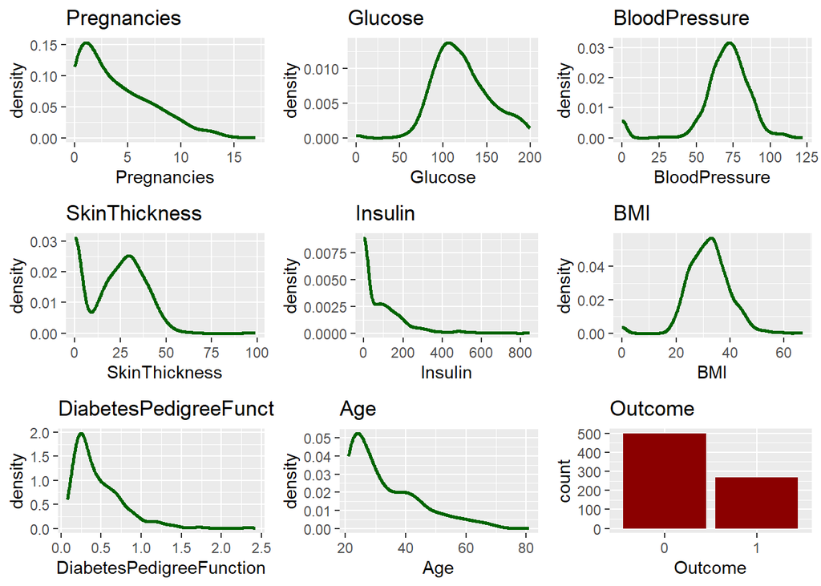

```r
plot1 <- ggplot(diabetes, aes(x = Pregnancies)) +
         geom_density(lwd=1, color="darkgreen") +
         ggtitle("Pregnancies")
plot2 <- ggplot(diabetes, aes(x = Glucose)) +
         geom_density(lwd=1, color="darkgreen") +
         ggtitle("Glucose")
plot3 <- ggplot(diabetes, aes(x = BloodPressure)) +
         geom_density(lwd=1, color="darkgreen") +
         ggtitle("BloodPressure")
plot4 <- ggplot(diabetes, aes(x = SkinThickness)) +
         geom_density(lwd=1, color="darkgreen") +
         ggtitle("SkinThickness")
plot5 <- ggplot(diabetes, aes(x = Insulin)) +
         geom_density(lwd=1, color="darkgreen") +
         ggtitle("Insulin")
plot6 <- ggplot(diabetes, aes(x = BMI)) +
         geom_density(lwd=1, color="darkgreen") +
         ggtitle("BMI")
plot7 <- ggplot(diabetes, aes(x = DiabetesPedigreeFunction)) +
         geom_density(lwd=1, color="darkgreen") +
         ggtitle("DiabetesPedigreeFunction")
plot8 <- ggplot(diabetes, aes(x = Age)) +
         geom_density(lwd=1, color="darkgreen") +
         ggtitle("Age")
plot9 <- ggplot(diabetes, aes(x = Outcome)) +
         geom_bar(fill="darkred") +
         ggtitle("Outcome")

# Mengatur grid 3x3
grid.arrange(
  plot1, plot2, plot3,
  plot4, plot5, plot6,
  plot7, plot8, plot9,
  ncol = 3
)
```

## 2.3 Kolom

### 2.3.1 Pregnancies

```r
summary(diabetes$Pregnancies)
```

```
##    Min. 1st Qu.  Median    Mean 3rd Qu.    Max.
##   0.000   1.000   3.000   3.845   6.000  17.000
```

```r
cat("Jumlah nilai 0:", num.zero[1], "\n")
```

```
## Jumlah nilai 0: 111
```

```r
cat("Persentase nilai 0:", pct.zero[1])
```

```
## Persentase nilai 0: 14.45
```

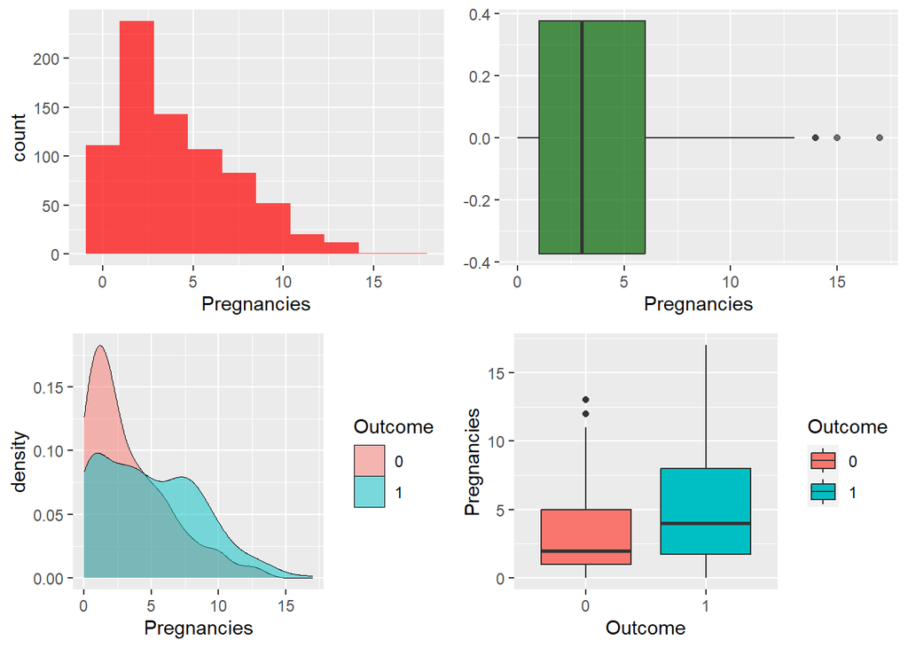

```r
plot1 <- ggplot(diabetes, aes(x = Pregnancies)) +
         geom_histogram(bins = 10, fill = "red", alpha = 0.7)
plot2 <- ggplot(diabetes, aes(x = Pregnancies)) +
         geom_boxplot(fill = "darkgreen", alpha=0.7)
plot3 <- ggplot(diabetes, aes(x = Pregnancies, group=Outcome)) +
         geom_density(lwd=0.1, aes(fill=Outcome), alpha= 0.5)
plot4 <- ggplot(diabetes, aes(y = Pregnancies, x=Outcome)) +
         geom_boxplot(aes(fill=Outcome))

# Mengatur grid
grid.arrange(
  plot1, plot2, plot3, plot4, ncol = 2
)
```

### 2.3.2 Glucose

```r
summary(diabetes$Glucose)
```

```
##    Min. 1st Qu.  Median    Mean 3rd Qu.    Max.
##     0.0    99.0   117.0   120.9   140.2   199.0
```

```r
cat("Jumlah nilai 0:", num.zero[2], "\n")
```

```
## Jumlah nilai 0: 5
```

```r
cat("Persentase nilai 0:", pct.zero[2])
```

```
## Persentase nilai 0: 0.65
```

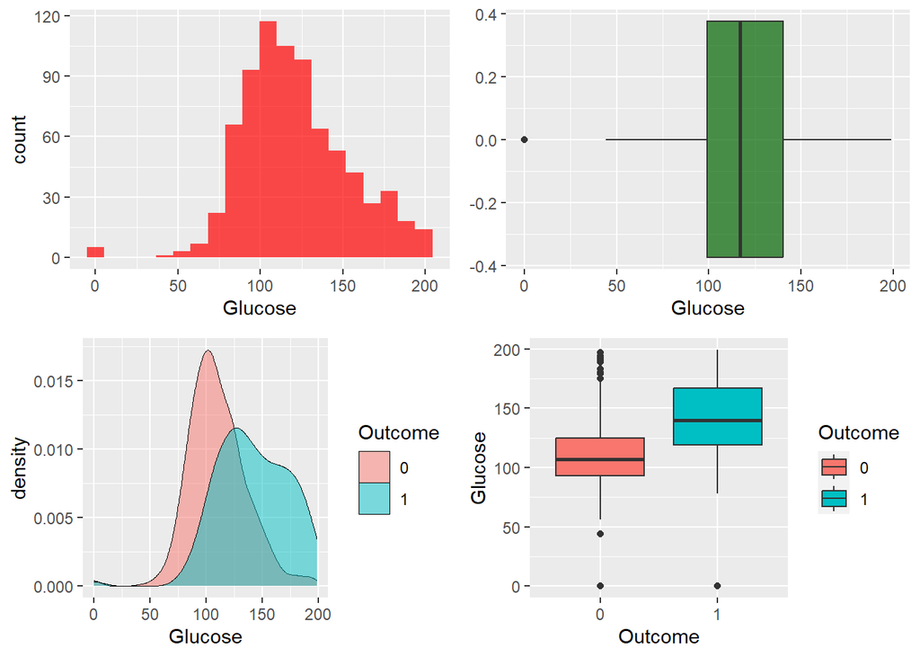

```r
plot1 <- ggplot(diabetes, aes(x = Glucose)) +
         geom_histogram(bins = 20, fill = "red", alpha = 0.7 )
plot2 <- ggplot(diabetes, aes(x = Glucose)) +
         geom_boxplot(fill = "darkgreen", alpha=0.7)
plot3 <- ggplot(diabetes, aes(x = Glucose, group=Outcome)) +
         geom_density(lwd=0.1, aes(fill=Outcome), alpha= 0.5)
plot4 <- ggplot(diabetes, aes(y = Glucose, x=Outcome)) +
         geom_boxplot(aes(fill=Outcome))

# Mengatur grid
grid.arrange(
  plot1, plot2, plot3, plot4, ncol = 2
)
```

### 2.3.3 Blood Pressure

```r
summary(diabetes$BloodPressure)
```

```
##    Min. 1st Qu.  Median    Mean 3rd Qu.    Max.
##    0.00   62.00   72.00   69.11   80.00  122.00
```

```r
cat("Jumlah nilai 0:", num.zero[3], "\n")
```

```
## Jumlah nilai 0: 35
```

```r
cat("Persentase nilai 0:", pct.zero[3])
```

```
## Persentase nilai 0: 4.56
```

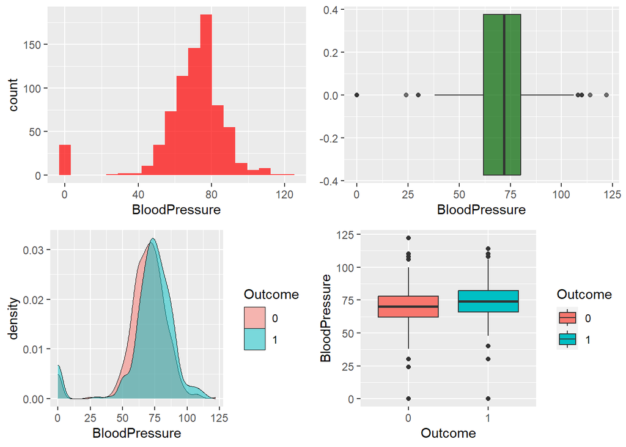

```r
plot1 <- ggplot(diabetes, aes(x = BloodPressure)) +
         geom_histogram(bins = 20, fill = "red", alpha = 0.7)
plot2 <- ggplot(diabetes, aes(x = BloodPressure)) +
         geom_boxplot(fill = "darkgreen", alpha=0.7)
plot3 <- ggplot(diabetes, aes(x = BloodPressure, group=Outcome)) +
         geom_density(lwd=0.1, aes(fill=Outcome), alpha= 0.5)
plot4 <- ggplot(diabetes, aes(y = BloodPressure, x=Outcome)) +
         geom_boxplot(aes(fill=Outcome))

# Mengatur grid
grid.arrange(
  plot1, plot2, plot3, plot4, ncol = 2
)
```

### 2.3.4 Skin Thickness

```r
summary(diabetes$SkinThickness)
```

```
##    Min. 1st Qu.  Median    Mean 3rd Qu.    Max.
##    0.00    0.00   23.00   20.54   32.00   99.00
```

```r
cat("Jumlah nilai 0:", num.zero[4], "\n")
```

```
## Jumlah nilai 0: 227
```

```r
cat("Persentase nilai 0:", pct.zero[4])
```

```
## Persentase nilai 0: 29.56
```

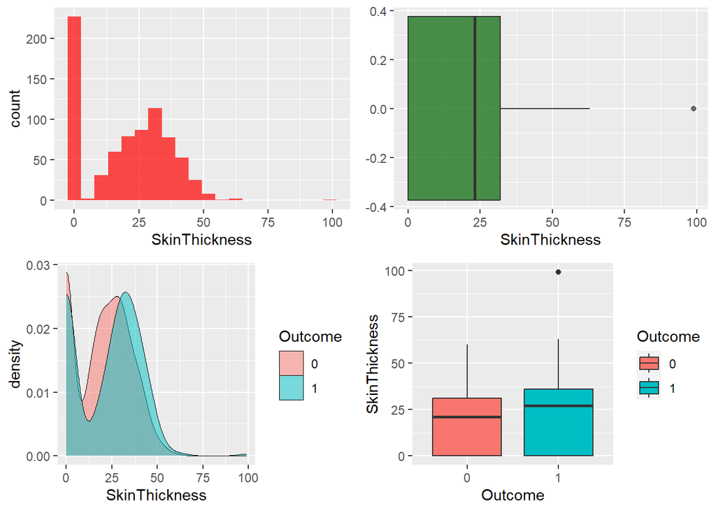

```r
plot1 <- ggplot(diabetes, aes(x = SkinThickness)) +
         geom_histogram(bins = 20, fill = "red", alpha = 0.7)
plot2 <- ggplot(diabetes, aes(x = SkinThickness)) +
         geom_boxplot(fill = "darkgreen", alpha=0.7)
plot3 <- ggplot(diabetes, aes(x = SkinThickness, group=Outcome)) +
         geom_density(lwd=0.1, aes(fill=Outcome), alpha= 0.5)
plot4 <- ggplot(diabetes, aes(y = SkinThickness, x=Outcome)) +
         geom_boxplot(aes(fill=Outcome))

# Mengatur grid
grid.arrange(
  plot1, plot2, plot3, plot4, ncol = 2
)
```

### 2.3.5 Insulin

```r
summary(diabetes$Insulin)
```

```
##    Min. 1st Qu.  Median    Mean 3rd Qu.    Max.
##     0.0     0.0    30.5    79.8   127.2   846.0
```

```r
cat("Jumlah nilai 0:", num.zero[5], "\n")
```

```
## Jumlah nilai 0: 374
```

```r
cat("Persentase nilai 0:", pct.zero[5])
```

```
## Persentase nilai 0: 48.7
```

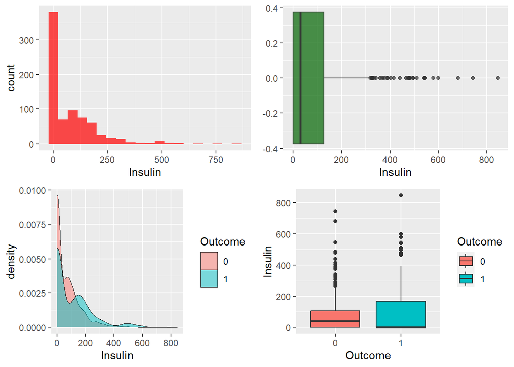

```r
plot1 <- ggplot(diabetes, aes(x = Insulin)) +
         geom_histogram(bins = 20, fill = "red", alpha = 0.7)
plot2 <- ggplot(diabetes, aes(x = Insulin)) +
         geom_boxplot(fill = "darkgreen", alpha=0.7)
plot3 <- ggplot(diabetes, aes(x = Insulin, group=Outcome)) +
         geom_density(lwd=0.1, aes(fill=Outcome), alpha= 0.5)
plot4 <- ggplot(diabetes, aes(y = Insulin, x=Outcome)) +
         geom_boxplot(aes(fill=Outcome))

# Mengatur grid
grid.arrange(
  plot1, plot2, plot3, plot4, ncol = 2
)
```

### 2.3.6 Body Mass Index

```r
summary(diabetes$BMI)
```

```
##    Min. 1st Qu.  Median    Mean 3rd Qu.    Max.
##    0.00   27.30   32.00   31.99   36.60   67.10
```

```r
cat("Jumlah nilai 0:", num.zero[6], "\n")
```

```
## Jumlah nilai 0: 11
```

```r
cat("Persentase nilai 0:", pct.zero[6])
```

```
## Persentase nilai 0: 1.43
```

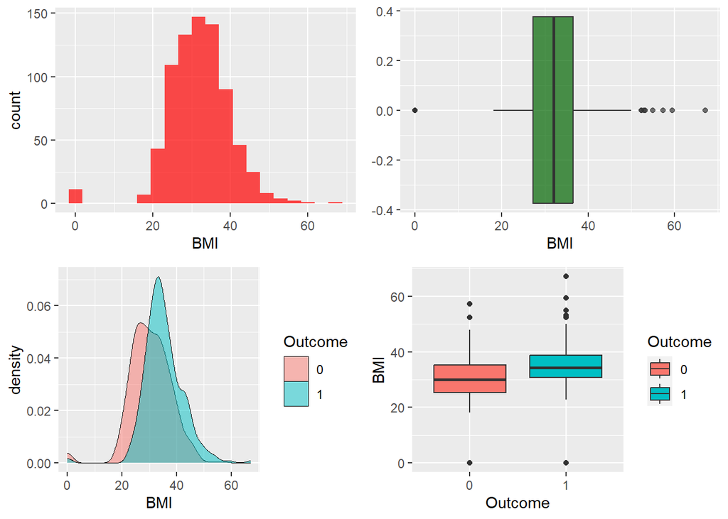

```r
plot1 <- ggplot(diabetes, aes(x = BMI)) +
         geom_histogram(bins = 20, fill = "red", alpha = 0.7)
plot2 <- ggplot(diabetes, aes(x = BMI)) +
         geom_boxplot(fill = "darkgreen", alpha=0.7)
plot3 <- ggplot(diabetes, aes(x = BMI, group=Outcome)) +
         geom_density(lwd=0.1, aes(fill=Outcome), alpha= 0.5)
plot4 <- ggplot(diabetes, aes(y = BMI, x=Outcome)) +
         geom_boxplot(aes(fill=Outcome))

# Mengatur grid
grid.arrange(
  plot1, plot2, plot3, plot4, ncol = 2
)
```

### 2.3.7 Diabetes Pedigree Function

```r
summary(diabetes$DiabetesPedigreeFunction)
```

```
##    Min. 1st Qu.  Median    Mean 3rd Qu.    Max.
##  0.0780  0.2437  0.3725  0.4719  0.6262  2.4200
```

```r
cat("Jumlah nilai 0:", num.zero[7], "\n")
```

```
## Jumlah nilai 0: 0
```

```r
cat("Persentase nilai 0:", pct.zero[7])
```

```
## Persentase nilai 0: 0
```

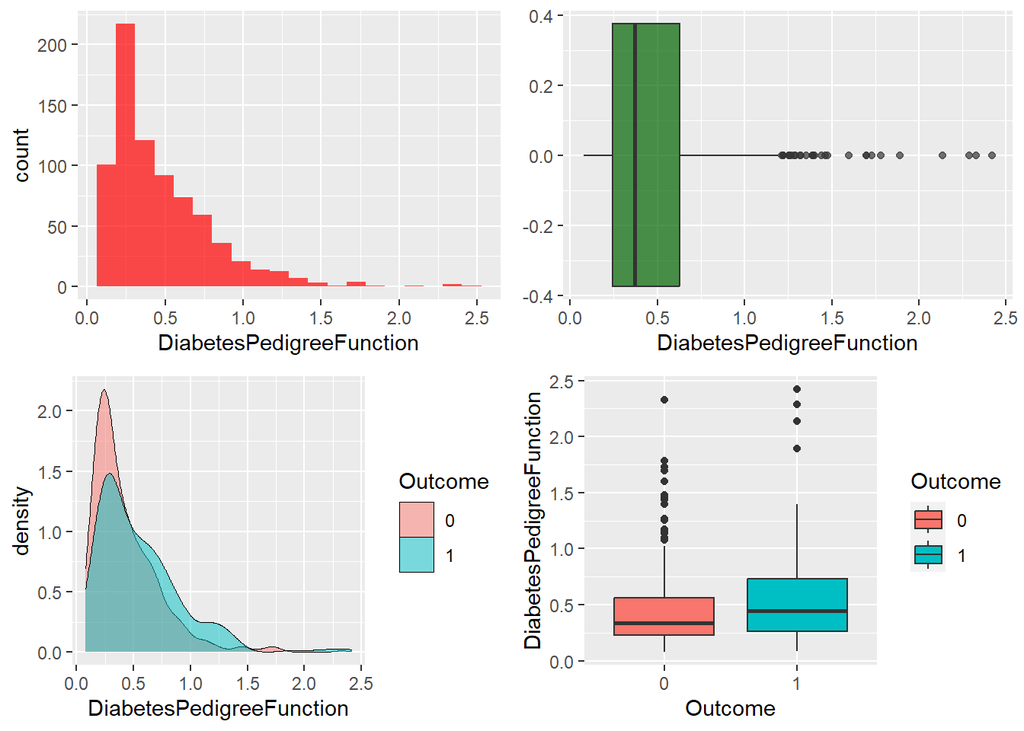

```r
plot1 <- ggplot(diabetes, aes(x = DiabetesPedigreeFunction)) +
         geom_histogram(bins = 20, fill = "red", alpha = 0.7)
plot2 <- ggplot(diabetes, aes(x = DiabetesPedigreeFunction)) +
         geom_boxplot(fill = "darkgreen", alpha=0.7)
plot3 <- ggplot(diabetes, aes(x = DiabetesPedigreeFunction, group=Outcome)) +
         geom_density(lwd=0.1, aes(fill=Outcome), alpha= 0.5)
plot4 <- ggplot(diabetes, aes(y = DiabetesPedigreeFunction, x=Outcome)) +
         geom_boxplot(aes(fill=Outcome))

# Mengatur grid
grid.arrange(
  plot1, plot2, plot3, plot4, ncol = 2
)
```

### 2.3.8 Age

```r
summary(diabetes$Age)
```

```
##    Min. 1st Qu.  Median    Mean 3rd Qu.    Max.
##   21.00   24.00   29.00   33.24   41.00   81.00
```

```r
cat("Jumlah nilai 0:", num.zero[8], "\n")
```

```
## Jumlah nilai 0: 0
```

```r
cat("Persentase nilai 0:", pct.zero[8])
```

```
## Persentase nilai 0: 0
```

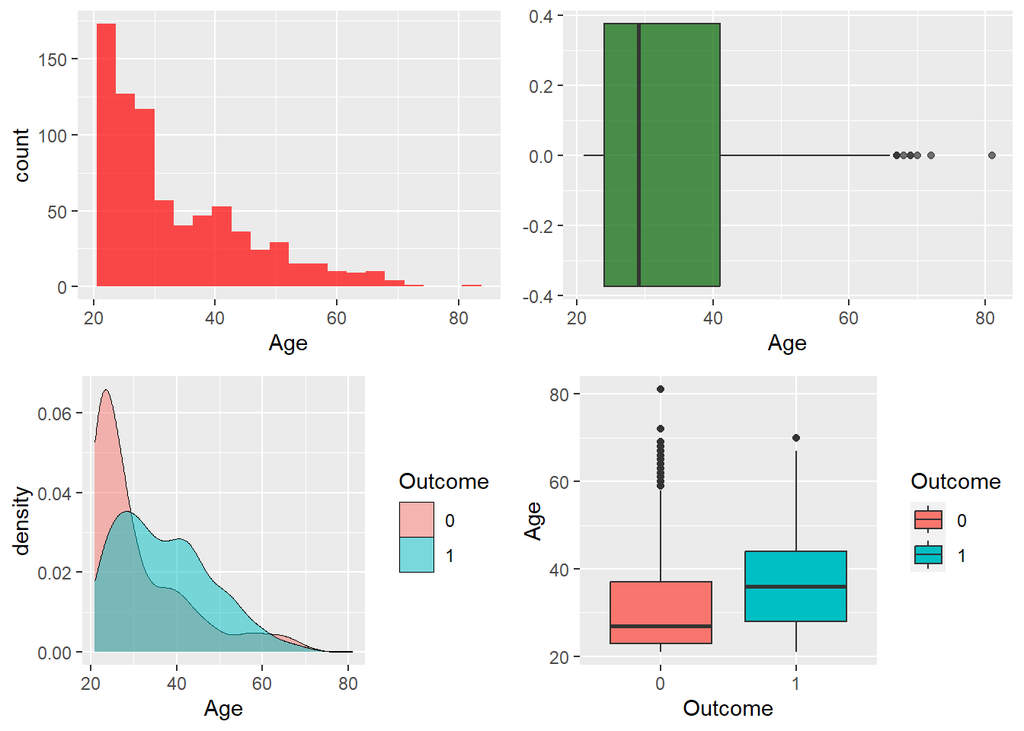

```r
plot1 <- ggplot(diabetes, aes(x = Age)) +
         geom_histogram(bins = 20, fill = "red", alpha = 0.7)
plot2 <- ggplot(diabetes, aes(x = Age)) +
         geom_boxplot(fill = "darkgreen", alpha=0.7)
plot3 <- ggplot(diabetes, aes(x = Age, group=Outcome)) +
         geom_density(lwd=0.1, aes(fill=Outcome), alpha= 0.5)
plot4 <- ggplot(diabetes, aes(y = Age, x=Outcome)) +
         geom_boxplot(aes(fill=Outcome))

# Mengatur grid
grid.arrange(
  plot1, plot2, plot3, plot4, ncol = 2
)
```

# 3 Outlier Analysis

Data yang digunakan merupakan data “cars” yang tersedia di R.

```r
head(cars)
```

```
##   speed dist
## 1     4    2
## 2     4   10
## 3     7    4
## 4     7   22
## 5     8   16
## 6     9   10
```

```r
summary(cars)
```

```
##      speed           dist
##  Min.   : 4.0   Min.   :  2.00
##  1st Qu.:12.0   1st Qu.: 26.00
##  Median :15.0   Median : 36.00
##  Mean   :15.4   Mean   : 42.98
##  3rd Qu.:19.0   3rd Qu.: 56.00
##  Max.   :25.0   Max.   :120.00
```

```r
str(cars)
```

```
## 'data.frame':    50 obs. of  2 variables:
##  $ speed: num  4 4 7 7 8 9 10 10 10 11 ...
##  $ dist : num  2 10 4 22 16 10 18 26 34 17 ...
```

```r
cars <- cars[1:30, ] # data awal diambil 30 baris pertama saja
```

## 3.1 Plot data awal tanpa outlier.

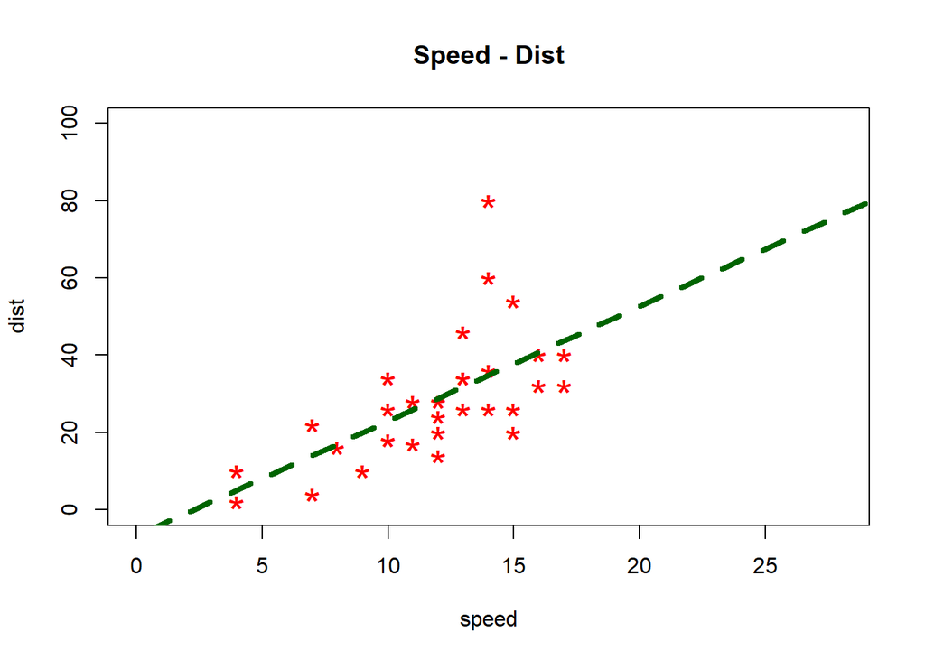

```r
plot(cars$speed, cars$dist, xlim=c(0, 28), ylim=c(0, 100),
     main="Speed - Dist", xlab="speed", ylab="dist",
     pch="*", col="red", cex=2)
abline(lm(dist ~ speed, data=cars), col="darkgreen", lwd=4, lty=2)
```

## 3.2 Penambahan outlier pada data

```r
cars_outliers <- data.frame(speed=c(24,24,25,25,25),
                            dist=c(81, 80, 86, 88, 85)) # introduce outliers.
cars_mod1 <- rbind(cars, cars_outliers)  # data dengan outlier.
cars_mod1
```

```
##    speed dist
## 1      4    2
## 2      4   10
## 3      7    4
## 4      7   22
## 5      8   16
## 6      9   10
## 7     10   18
## 8     10   26
## 9     10   34
## 10    11   17
## 11    11   28
## 12    12   14
## 13    12   20
## 14    12   24
```

[output cut: 21 more lines]

## 3.3 Plot data dengan outlier.

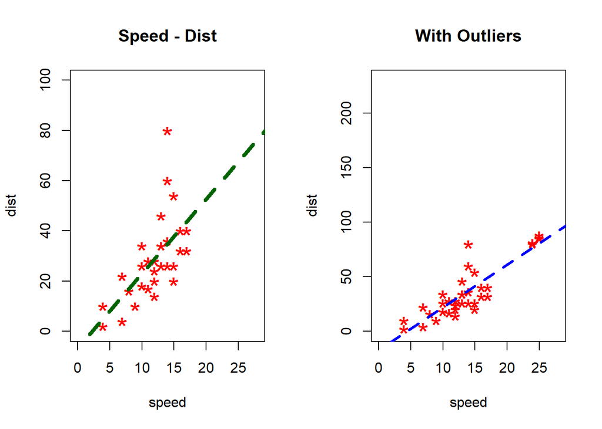

```r
par(mfrow=c(1, 2))
# Plot data awal tanpa outlier.
model_1 = lm(dist ~ speed, data=cars)
plot(cars$speed, cars$dist, xlim=c(0, 28), ylim=c(0, 100),
     main="Speed - Dist", xlab="speed", ylab="dist",
     pch="*", col="red", cex=2)
abline(model_1, col="darkgreen", lwd=4, lty=2)

model_2 = lm(dist ~ speed, data=cars_mod1)        # lm = linear model
plot(cars_mod1$speed, cars_mod1$dist, xlim=c(0, 28), ylim=c(0, 230),
     main="With Outliers", xlab="speed", ylab="dist",
     pch="*", col="red", cex=2)
abline(model_2, col="blue", lwd=3, lty=2)
```

```r
model_1
```

```
##
## Call:
## lm(formula = dist ~ speed, data = cars)
##
## Coefficients:
## (Intercept)        speed
##      -6.845        2.973
```

```r
model_2
```

```
##
## Call:
## lm(formula = dist ~ speed, data = cars_mod1)
##
## Coefficients:
## (Intercept)        speed
##     -17.129        3.905
```

```r
cars_outliers <- data.frame(speed=c(24,24,25,25,25), dist=c(81, 80, 86, 88, 85))  # introduce outliers.

# menambahkan data outlier pada data cars yang asli
cars_mod2 <- rbind(cars, cars_outliers)  # data dengan amatan berpengaruh.
View(cars_mod2)

length(cars_mod2$speed)
```

```
## [1] 35
```

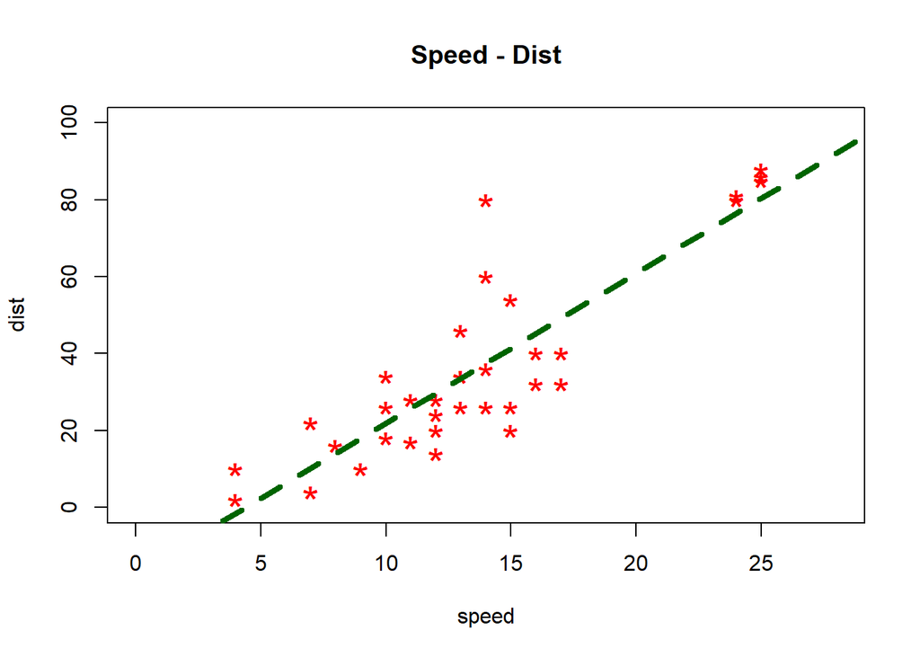

```r
model_3 = lm(dist ~ speed, data=cars_mod2)
plot(cars_mod2$speed, cars_mod2$dist, xlim=c(0, 28), ylim=c(0, 100),
     main="Speed - Dist", xlab="speed", ylab="dist",
     pch="*", col="red", cex=2)
abline(model_3, col="darkgreen", lwd=4, lty=2)
```

```r
summary(model_3)
```

```
##
## Call:
## lm(formula = dist ~ speed, data = cars_mod2)
##
## Residuals:
##     Min      1Q  Median      3Q     Max
## -21.453  -8.425   0.358   4.993  42.453
##
## Coefficients:
##             Estimate Std. Error t value Pr(>|t|)
## (Intercept) -17.1288     5.8048  -2.951  0.00579 **
## speed         3.9054     0.3928   9.943 1.87e-11 ***
## ---
## Signif. codes:  0 '***' 0.001 '**' 0.01 '*' 0.05 '.' 0.1 ' ' 1
##
## Residual standard error: 12.63 on 33 degrees of freedom
## Multiple R-squared:  0.7498, Adjusted R-squared:  0.7422
## F-statistic: 98.87 on 1 and 33 DF,  p-value: 1.866e-11
```

```r
influence.measures(model_3)
```

```
## Influence measures of
##   lm(formula = dist ~ speed, data = cars_mod2) :
##
##      dfb.1_  dfb.sped    dffit cov.r   cook.d    hat inf
## 1   0.10699 -0.094246  0.10793 1.203 5.99e-03 0.1203   *
## 2   0.35568 -0.313326  0.35881 1.141 6.45e-02 0.1203
## 3  -0.13469  0.109816 -0.14107 1.129 1.02e-02 0.0725
## 4   0.25846 -0.210730  0.27070 1.082 3.67e-02 0.0725
## 5   0.03571 -0.027935  0.03847 1.130 7.63e-04 0.0604
## 6  -0.13203  0.097683 -0.14860 1.091 1.12e-02 0.0503
## 7  -0.05451  0.037223 -0.06565 1.103 2.22e-03 0.0421
## 8   0.05658 -0.038642  0.06815 1.103 2.39e-03 0.0421
## 9   0.16988 -0.116012  0.20460 1.047 2.10e-02 0.0421
## 10 -0.10178  0.061347 -0.13621 1.069 9.42e-03 0.0358
## 11  0.02482 -0.014960  0.03321 1.101 5.68e-04 0.0358
```

[output cut: 24 more lines]

```r
summary(model_1)
```

```
##
## Call:
## lm(formula = dist ~ speed, data = cars)
##
## Residuals:
##     Min      1Q  Median      3Q     Max
## -17.751  -8.818  -1.993   2.885  45.222
##
## Coefficients:
##             Estimate Std. Error t value Pr(>|t|)
## (Intercept)  -6.8446     8.7420  -0.783 0.440223
## speed         2.9730     0.7046   4.219 0.000233 ***
## ---
## Signif. codes:  0 '***' 0.001 '**' 0.01 '*' 0.05 '.' 0.1 ' ' 1
##
## Residual standard error: 13.1 on 28 degrees of freedom
## Multiple R-squared:  0.3887, Adjusted R-squared:  0.3669
## F-statistic:  17.8 on 1 and 28 DF,  p-value: 0.0002327
```

# 4 Outlier: Data BPR

```r
setwd("D:/Kuliah/Mat/TSA Kominfo/Praktikum")  # set working directory
bpr <- read.csv("2. eksplorasi01.csv")
head(bpr)
```

```
##   Kode.Bank Non.Performing.Loan Growth.Laba.Rugi.Berjalan Spread.Margin
## 1         1            10.49833                 11.538745     11.611141
## 2         2            15.27000                -11.188068     11.691391
## 3         3             1.63000                  9.325274      3.620513
## 4         4            27.65167                  8.167480     12.871722
## 5         5            51.32000                 26.825480     14.429154
## 6         6             9.03000                 13.969876      3.836760
##   Cash.Ratio Modal.inti.thdp.Aset      BOPO Ratio.Kredit.thdp.DPK
## 1   21.76331           0.09385150 0.9067301             0.9671143
## 2   14.10585           0.09061287 1.4005322             1.4584551
## 3   18.23885           0.08618314 0.7979953             0.9339539
## 4   66.29771           0.05432665 1.6785487             1.2375042
## 5   29.92377           0.28228712 1.3184079             0.8857992
## 6   50.76537           0.14190734 0.8538458             1.5697280
##   Rasio.biaya.tenaga.thd.pendapatan.operasional
## 1                                     0.3536502
## 2                                     0.7167977
## 3                                     0.3055795
## 4                                     0.2392941
## 5                                     0.5862838
## 6                                     0.2692363
##   Rasio.Pendapatan.Operasional.thd.Aset.Produktif
## 1                                       0.2591038
## 2                                       0.1616119
## 3                                       0.1904516
## 4                                       0.2774885
## 5                                       0.3958143
## 6                                       0.2129047
```

```r
str(bpr)
```

```
## 'data.frame':    147 obs. of  10 variables:
##  $ Kode.Bank                                      : int  1 2 3 4 5 6 7 8 9 10 ...
##  $ Non.Performing.Loan                            : num  10.5 15.27 1.63 27.65 51.32 ...
##  $ Growth.Laba.Rugi.Berjalan                      : num  11.54 -11.19 9.33 8.17 26.83 ...
##  $ Spread.Margin                                  : num  11.61 11.69 3.62 12.87 14.43 ...
##  $ Cash.Ratio                                     : num  21.8 14.1 18.2 66.3 29.9 ...
##  $ Modal.inti.thdp.Aset                           : num  0.0939 0.0906 0.0862 0.0543 0.2823 ...
##  $ BOPO                                           : num  0.907 1.401 0.798 1.679 1.318 ...
##  $ Ratio.Kredit.thdp.DPK                          : num  0.967 1.458 0.934 1.238 0.886 ...
##  $ Rasio.biaya.tenaga.thd.pendapatan.operasional  : num  0.354 0.717 0.306 0.239 0.586 ...
##  $ Rasio.Pendapatan.Operasional.thd.Aset.Produktif: num  0.259 0.162 0.19 0.277 0.396 ...
```

```r
summary(bpr)
```

```
##    Kode.Bank     Non.Performing.Loan Growth.Laba.Rugi.Berjalan
##  Min.   :  1.0   Min.   : 0.3433     Min.   :-679.401
##  1st Qu.: 37.5   1st Qu.: 4.9733     1st Qu.:   9.668
##  Median : 74.0   Median : 9.5683     Median :  13.085
##  Mean   : 74.0   Mean   :14.1751     Mean   :  90.354
##  3rd Qu.:110.5   3rd Qu.:19.4375     3rd Qu.:  20.382
##  Max.   :147.0   Max.   :61.6100     Max.   :8406.827
##
##  Spread.Margin       Cash.Ratio      Modal.inti.thdp.Aset      BOPO
##  Min.   :-47.267   Min.   :  4.904   Min.   :-0.40167     Min.   :0.6342
##  1st Qu.:  8.627   1st Qu.: 18.125   1st Qu.: 0.09245     1st Qu.:0.8926
##  Median : 11.219   Median : 25.903   Median : 0.12070     Median :0.9734
##  Mean   : 10.841   Mean   : 37.481   Mean   : 0.15401     Mean   :1.0727
##  3rd Qu.: 13.804   3rd Qu.: 41.177   3rd Qu.: 0.19269     3rd Qu.:1.1209
##  Max.   : 50.109   Max.   :458.130   Max.   : 0.71460     Max.   :2.4607
##  NA's   :15
##  Ratio.Kredit.thdp.DPK Rasio.biaya.tenaga.thd.pendapatan.operasional
##  Min.   :0.5961        Min.   :0.1562
##  1st Qu.:0.9678        1st Qu.:0.2773
##  Median :1.1626        Median :0.3502
##  Mean   :1.3924        Mean   :0.3882
##  3rd Qu.:1.5659        3rd Qu.:0.4707
##  Max.   :4.1955        Max.   :1.1470
##
##  Rasio.Pendapatan.Operasional.thd.Aset.Produktif
##  Min.   :0.1346
##  1st Qu.:0.1954
##  Median :0.2200
##  Mean   :0.2292
##  3rd Qu.:0.2517
##  Max.   :0.4427
##
```

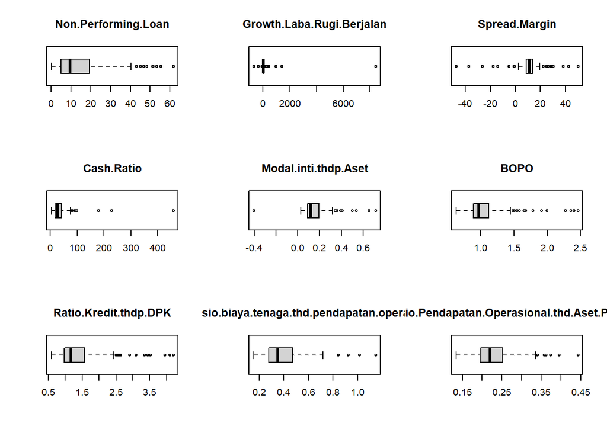

```r
par0 <- par(mfrow=c(3,3))
for (i in 2:10) boxplot(bpr[,i], main=colnames(bpr)[i], horizontal = TRUE)
```

```r
par(par0)
```

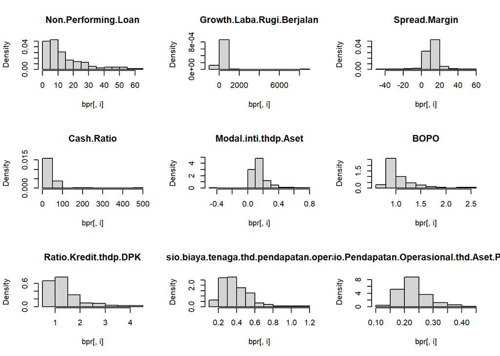

```r
par0 <- par(mfrow=c(3,3))
for (i in 2:10) hist(bpr[,i], main=colnames(bpr)[i], freq = FALSE)
```